# Player choices

How do you allow the player to make choices in a conversation? This is what we will see in this lesson. The hardest part with choices is really writing branching conversations.

In visual novels, like most dialogue-heavy games, choices can open branches that soon close back down. Even in a game like Mass Effect, that *feels* like you have so much control over the story, most choices affect only one or several lines of dialogue. The challenge is figuring out how to close these little arcs down while giving the illusion of control to the player.

The reason is just the sheer amount of work involved in writing different dialogues and, for big games, related animations, camera placement, and voice-over to record.

Anyway, let’s get to the choice system’s design. I went for a plain vertical list: it takes advantage of the text box’s panel and displays inside of it.

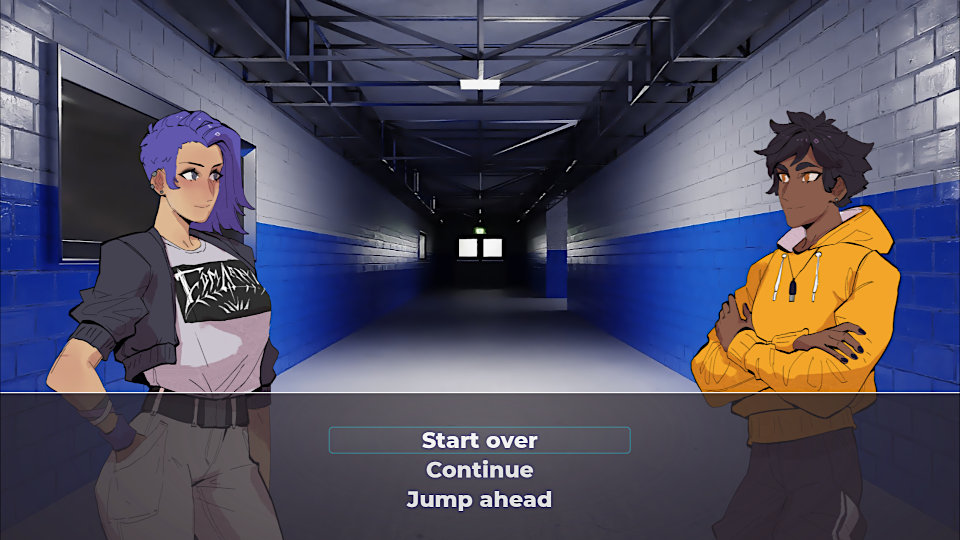

It’s a little reminiscent of my RPG Maker days.

When the `ScenePlayer` reaches a player choice, we hide the name label and the text, and display a list of options in the middle.

Create a new scene with a

[figure not shown]

`VBoxContainer` node as the root and name it *ChoiceSelector*. This will be the only node in this scene as we’ll create buttons programmatically.

Apply *Layout -> Full Rect* to make the node span the entire viewport. It will make the node expand to fit its parent’s bounding-box by default.

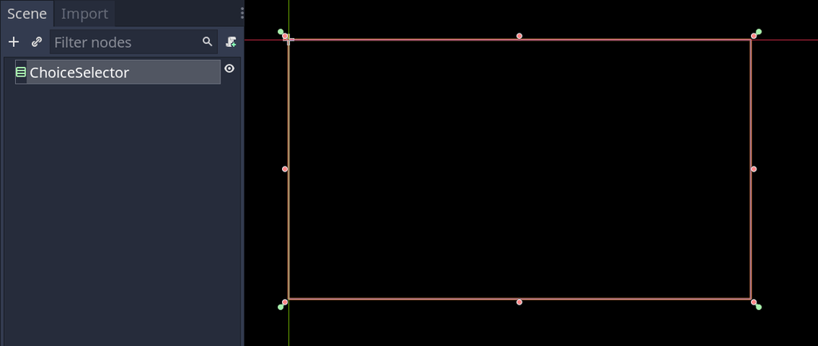

You can save the scene in the `TextBox/` folder and attach a script to the *ChoiceSelector*.

## Adding button styles to the theme

The default buttons don’t work well at all with our text box’s look.

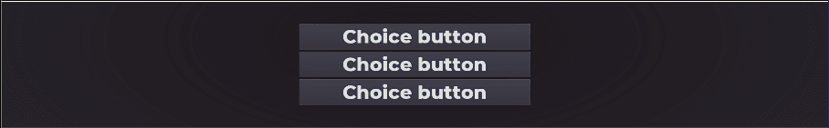

We need to update our theme resource to fix that.

Open `theme.tres` and in the *Theme* bottom panel, click *Edit Theme -> Add Class Items*, set the *Type* to “Button” and click *Add All*.

You should see a new button category appear in the *Inspector*, below the *Default Font* property. Expand it and expand the styles subcategory.

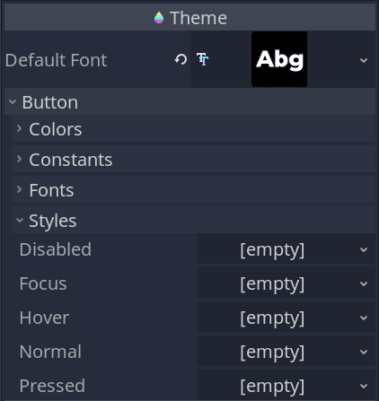

There, you can add resources that change the look of the buttons’ background. We will make the button transparent in most of its states, so only its text stays visible. The only exception is the focus state, which will highlight the currently selected button.

Right-click on *Styles -> Disabled* and create a new *StyleBoxEmpty*. This resource type doesn’t draw anything, making the button’s background transparent in its disabled state.

Do the same for the *Hover*, *Normal*, and *Pressed* styles. In the theme preview, you should now only see the text “Button” without a background or border, and that even if you hover it with the mouse or press it.

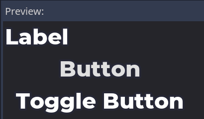

We want to add a different style to the *Focus* state to outline the player’s selected choice.

Right-click the field next to *Focus* and create a new *StyleBoxFlat*. Click on the resource to edit it.

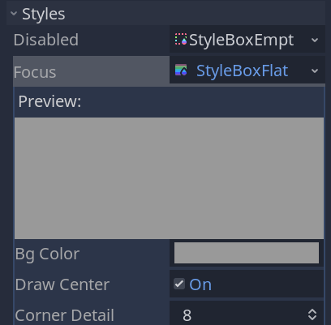

This resource defines a simple geometric shape with a background color, a border, round corners, and optional shadow and content margins.

It results in a mostly flat panel and works well when you have simple needs.

I set the *Bg Color* to a barely visible light blue, with an alpha value of `11`.

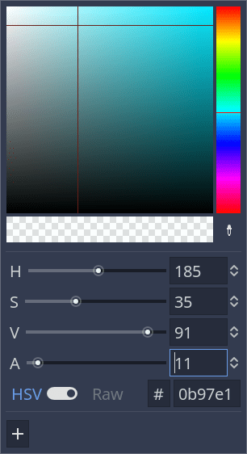

Then, to give focused buttons an outline, set the *Border Width* *Left*, *Top*, *Right*, and *Bottom* to `2` pixels. For the *Border Color*, I used a transparent light and saturated blue.

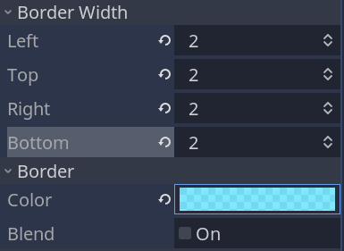

To round the corners, set the four *Corner Radius* properties value of `8` pixels. These values control the radius of each corner.

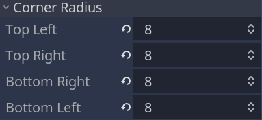

With that, you can click on the button in the *Preview* to see an outline appear around it.

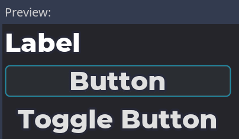

With that, we can start coding.

## Coding the choices

Open the `ChoiceSelector.gd` script. In it, we’ll define a `display()` function.

The `display()` function will directly use data from the `ScenePlayer`’s `_scene_data`. Each choice needs a label that will display as text and a number representing the next key to target in the scene player.

Every time we display choices, we create buttons and connect to that pressed signal. We bind the `target` value to the `_on_Button_pressed()` callback.

```
# Displays a list of choices the player can navigate and select from.
class_name ChoiceSelector
extends VBoxContainer

## Emitted when the player presses one of the choice buttons.
signal choice_made(target_id)


# Individual choices are dictionaries with a `label` and a `target` key.
# We get choices as an array of dictionaries and create a button for each of
# them.
func display(choices: Array) -> void:
    for choice in choices:
        var button := Button.new()
        button.text = choice.label
        # We bind the target node key to the `_on_Button_pressed()` callback
        # function as we need to emit it along with the `choice_made` signal.
        button.connect("pressed", self, "_on_Button_pressed", [choice.target])
        add_child(button)
    # We give the first button focus, allowing the player to navigate them with
    # the keyboard.
    (get_child(0) as Button).grab_focus()
```

Whenever the player makes a choice, we delete all the buttons and emit the target ID.

```
func _on_Button_pressed(target_id: int) -> void:
    emit_signal("choice_made", target_id)
    _clear()


func _clear() -> void:
    for child in get_children():
        child.queue_free()
```

The data I chose for choices looks like the following. It’s an array of dictionaries, each containing a `label` and `target` key.

```
[
    {label = "Hi Sophia!", target = 5},
    {label = "Do I know you?", target = 6},
    {label = "Get out of my way!", target = 7}
]
```

## Adding choices to the TextBox

Next, we need to wire the `ChoiceSelector` to the `TextBox` and the `ScenePlayer`.

Open the `TextBox` scene and create an instance of the `ChoiceSelector` as a child of the *TextBox* node.

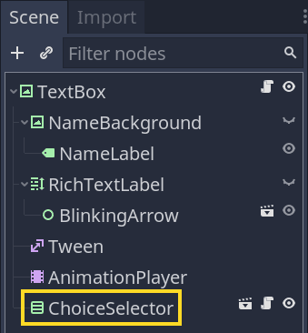

To preview its look, you can add buttons as children of it with some placeholder text.

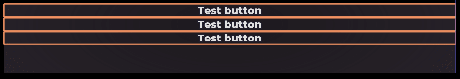

By default, they expand to fill the

[figure not shown]

`VBoxContainer` horizontally, making them too large.

We can address that by resizing the *ChoiceSelector*. It should take between 20 and 30% of the panel’s width.

You also want to adjust the vertical margins so the buttons don’t touch the text box’s top edge.

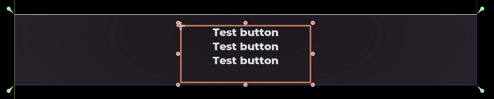

Once you are satisfied with the size and margins, delete the buttons as we’ll generate them as needed using code.

To display choices, we define a new `display_choices()` function on the `TextBox` script. It should hide the *RichTextLabel* and any element we don’t want to have visible, then delegate choices to the selector.

When the player decided, we bubble up the `ChoiceSelector.choice_made` signal and reset the scene’s visibility.

Add the following code to `TextBox.gd`.

```
## Emitted when the player made a choice. The argument is the ID of the target
## scene node to jump to.
signal choice_made(target_id)

onready var _choice_selector: ChoiceSelector = $ChoiceSelector
onready var _name_background: TextureRect = $NameBackground

func _ready() -> void:
    #...
    ## The text box forwards the `choice_made` signal to the scene player via a
    ## signal.
    _choice_selector.connect("choice_made", self, "_on_ChoiceSelector_choice_made")


# As the choices live as a child of the text box, we have to hide nodes manually,
# which we do here.
# The scene player can call this method to display choices.
func display_choice(choices: Array) -> void:
    _name_background.hide()
    _rich_text_label.hide()
    _blinking_arrow.hide()

    _choice_selector.display(choices)


# When the player made a choice, we forward the signal to the scene player so it
# can jump to the node corresponding to `target_id`. And we reset
# visibility.
func _on_ChoiceSelector_choice_made(target_id: int) -> void:
    emit_signal("choice_made", target_id)
    _name_background.show()
    _rich_text_label.show()
```

In the scene player’s `run_scene()` function, we add a new block to manage choices. If the current node has a key named “choices”, we call `TextBox.display_choice()` and wait for it to emit the `choice_made` signal. It gives us the index of our next key.

At this point, we can also add support for restarting the scene, for lack of a better place to cover this bite-sized feature.

Open `ScenePlayer.gd` and add the following code.

```
## Emitted when a scene node contains an instruction to restart the scene. You
## could do that when you make a choice that leads you to a game over, for
## instance.
signal restart_requested

const KEY_RESTART_SCENE := -2


func run_scene() -> void:
    #...
    #while key != KEY_END_OF_SCENE:
        #...
        #if "line" in node:
            #...
        #elif "transition" in node:
            #...
        elif "choices" in node:
            _text_box.display_choice(node.choices)
            # The text box's `choice_made` signal returns the key of the node
            # corresponding to the choice the player made.
            key = yield(_text_box, "choice_made")
            # If the choice causes a scene restart, we emit a signal and end the
            # function.
            # A higher-level system will take care of reloading the scene.
            if key == KEY_RESTART_SCENE:
                emit_signal("restart_requested")
                return
        #else:
            #...
```

Our restart mechanism is basic here, but note you could use similar logic to have nodes that request jumping to a specific scene depending on the player’s choices.

To test the choices, you can set `ScenePlayer._scene_data` to the following. It’ll fade the scene in and display three choices. All options end the scene as we lack more steps to play with.

Also, be sure to call `run_scene()` from within `_ready()`.

```
var _scene_data := {
    0: {
        transition = "fade_in",
        next = 1
    },
    1: {
        choices = [
            {label = "Hi Sophia!", target = -1},
            {label = "Do I know you?", target = -1},
            {label = "Get out of my way!", target = -1},
        ],
    }
}
```

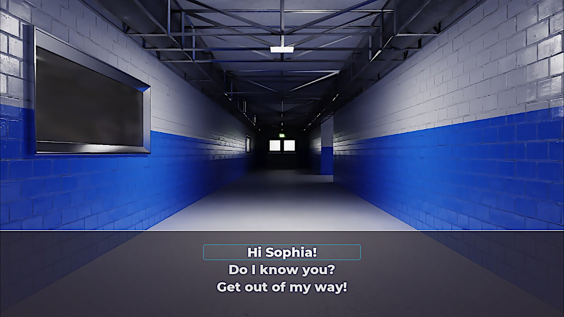

With that, we’re getting close to having every feature in place.

In the next lesson, we’ll add a “main” node to our game, which will take care of sequencing scenes.

## Code reference

Here are the complete scripts for the files we modified in this lesson.

`ChoiceSelector.gd`

```
class_name ChoiceSelector
extends VBoxContainer

signal choice_made(target_id)


func display(choices: Array) -> void:
    for choice in choices:
        var button := Button.new()
        button.text = choice.label
        button.connect("pressed", self, "_on_Button_pressed", [choice.target])
        add_child(button)
    (get_child(0) as Button).grab_focus()


func _on_Button_pressed(target_id: int) -> void:
    emit_signal("choice_made", target_id)
    _clear()


func _clear() -> void:
    for child in get_children():
        child.queue_free()
```

`TextBox.gd`

```
extends Control

signal display_finished
signal next_requested
signal choice_made(target_id)

export var display_speed := 20.0
export var bbcode_text := "" setget set_bbcode_text

onready var _rich_text_label: RichTextLabel = $RichTextLabel
onready var _name_label: Label = $NameBackground/NameLabel
onready var _blinking_arrow: Control = $RichTextLabel/BlinkingArrow
onready var _tween: Tween = $Tween
onready var _anim_player: AnimationPlayer = $AnimationPlayer
onready var _choice_selector: ChoiceSelector = $ChoiceSelector
onready var _name_background: TextureRect = $NameBackground


func _ready() -> void:
    hide()
    _blinking_arrow.hide()

    _name_label.text = ""
    _rich_text_label.bbcode_text = ""
    _rich_text_label.visible_characters = 0

    _tween.connect("tween_all_completed", self, "_on_Tween_tween_all_completed")
    _choice_selector.connect("choice_made", self, "_on_ChoiceSelector_choice_made")


func _unhandled_input(event: InputEvent) -> void:
    if event.is_action_pressed("ui_accept"):
        if _blinking_arrow.visible:
            emit_signal("next_requested")
        else:
            _tween.seek(INF)


func display(text: String, character_name := "", speed := display_speed) -> void:
    set_bbcode_text(text)

    if speed != display_speed:
        display_speed = speed

    if character_name != "":
        _name_label.text = character_name


func set_bbcode_text(text: String) -> void:
    bbcode_text = text
    if not is_inside_tree():
        yield(self, "ready")

    _blinking_arrow.hide()
    _rich_text_label.bbcode_text = bbcode_text
    call_deferred("_begin_dialogue_display")


func fade_in_async() -> void:
    _anim_player.play("fade_in")
    _anim_player.seek(0.0, true)
    yield(_anim_player, "animation_finished")


func fade_out_async() -> void:
    _anim_player.play("fade_out")
    yield(_anim_player, "animation_finished")


func display_choice(choices: Array) -> void:
    _name_background.hide()
    _rich_text_label.hide()
    _blinking_arrow.hide()

    _choice_selector.display(choices)


func _begin_dialogue_display() -> void:
    var character_count := _rich_text_label.get_total_character_count()
    _tween.interpolate_property(
        _rich_text_label, "visible_characters", 0, character_count, character_count / display_speed
    )
    _tween.start()


func _on_Tween_tween_all_completed() -> void:
    emit_signal("display_finished")
    _blinking_arrow.show()


func _on_ChoiceSelector_choice_made(target_id: int) -> void:
    emit_signal("choice_made", target_id)
    _name_background.show()
    _rich_text_label.show()
```

`ScenePlayer.gd`

```
class_name ScenePlayer
extends Node

signal scene_finished
signal transition_finished
signal restart_requested

const KEY_END_OF_SCENE := -1
const KEY_RESTART_SCENE := -2

const TRANSITIONS := {
    fade_in = "_appear_async",
    fade_out = "_disappear_async",
}

var _scene_data := {}

onready var _text_box := $TextBox
onready var _character_displayer := $CharacterDisplayer
onready var _background := $Background
onready var _anim_player: AnimationPlayer = $FadeAnimationPlayer


func run_scene() -> void:
    var key = _scene_data.keys()[0]
    while key != KEY_END_OF_SCENE:
        var node: Dictionary = _scene_data[key]

        var character: Character = (
            ResourceDB.get_character(node.character)
            if "character" in node
            else ResourceDB.get_narrator()
        )

        if "background" in node:
            var bg: Background = ResourceDB.get_background(node.background)
            _background.texture = bg.texture

        if "character" in node:
            var side: String = node.side if "side" in node else CharacterDisplayer.SIDE.LEFT
            var animation: String = node.get("animation", "")
            var expression: String = node.get("expression", "")
            _character_displayer.display(character, side, expression, animation)
            if not "line" in node:
                yield(_character_displayer, "display_finished")

        if "line" in node:
            _text_box.display(node.line, character.display_name)
            yield(_text_box, "next_requested")
            key = node.next
        elif "transition" in node:
            call(TRANSITIONS[node.transition])
            yield(self, "transition_finished")
            key = node.next

        elif "choices" in node:
            _text_box.display_choice(node.choices)
            key = yield(_text_box, "choice_made")
            if key == KEY_RESTART_SCENE:
                emit_signal("restart_requested")
                return
        else:
            key = node.next

    _character_displayer.hide()
    emit_signal("scene_finished")


func _appear_async() -> void:
    _anim_player.play("fade_in")
    yield(_anim_player, "animation_finished")
    yield(_text_box.fade_in_async(), "completed")
    emit_signal("transition_finished")


func _disappear_async() -> void:
    yield(_text_box.fade_out_async(), "completed")
    _anim_player.play("fade_out")
    yield(_anim_player, "animation_finished")
    emit_signal("transition_finished")
```